# Testing for association between two continous variables

Esko, commented by Markus

22.08.2016

## Dataset

We will load the dataset created in section *Merging two data frames*, where we combined the dataset containing game performance data with that containing working memory test data.

```r
game.wmc <- read.table("kr_gamewmc.txt", header=T)
```

## Question: Is accuracy in the game associated with working memory capacity?

Let’s calculate *accuracy* anew:

```r
game.wmc$accuracy <- game.wmc$Phit + game.wmc$PcorrectRejection
```

In order to visualize an association between two continous variables, a scatter plot would be perfect.

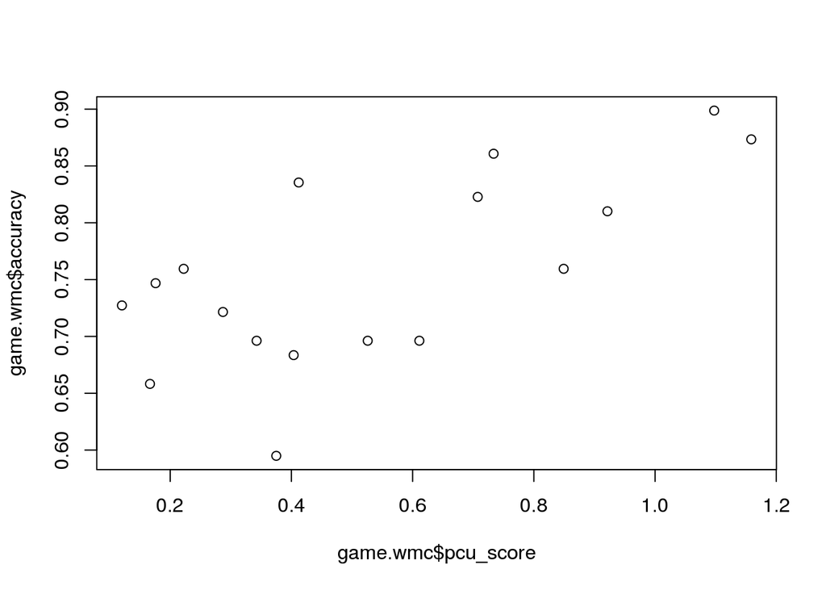

```r
plot(game.wmc$pcu_score, game.wmc$accuracy)
```

We can also calculate Pearson correlation (the default for the function *cor*).

```r
cor(game.wmc$pcu_score, game.wmc$accuracy)
```

```
## [1] NA
```

```r
cor(game.wmc$pcu_score, game.wmc$accuracy, use="complete.obs")
```

```
## [1] 0.6813248
```

With cor.test, it is possible to calculate the significance of the correlation, also. Note that missing values are removed by default.

```r
cor.test(game.wmc$pcu_score, game.wmc$accuracy)
```

```
##
##  Pearson's product-moment correlation
##
## data:  game.wmc$pcu_score and game.wmc$accuracy
## t = 3.605, df = 15, p-value = 0.002599
## alternative hypothesis: true correlation is not equal to 0
## 95 percent confidence interval:
##  0.298398 0.875323
## sample estimates:
##       cor
## 0.6813248
```

We could also use a linear regression model to predict accuracy based on the working memory score.

```r
fm <- lm(accuracy ~ pcu_score, game.wmc)
summary(fm)
```

```
##
## Call:
## lm(formula = accuracy ~ pcu_score, data = game.wmc)
##
## Residuals:
##       Min        1Q    Median        3Q       Max
## -0.132393 -0.048786  0.009514  0.045519  0.101660
##
## Coefficients:
##             Estimate Std. Error t value Pr(>|t|)
## (Intercept)  0.66200    0.03012  21.981    8e-13 ***
## pcu_score    0.17422    0.04833   3.605   0.0026 **
## ---
## Signif. codes:  0 '***' 0.001 '**' 0.01 '*' 0.05 '.' 0.1 ' ' 1
##
## Residual standard error: 0.06337 on 15 degrees of freedom
##   (1 observation deleted due to missingness)
## Multiple R-squared:  0.4642, Adjusted R-squared:  0.4285
## F-statistic:    13 on 1 and 15 DF,  p-value: 0.002599
```

The function *summary* is useful for inspecting the model. The fitted model can be also given to plot command, which produces plots related to regression diagnostics.

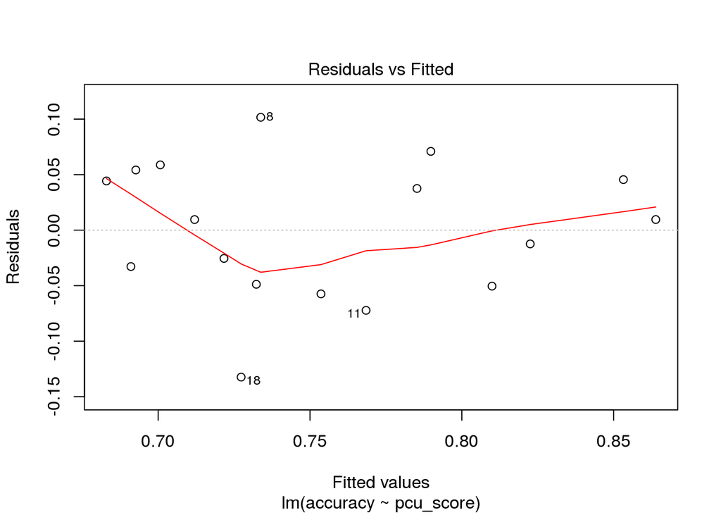

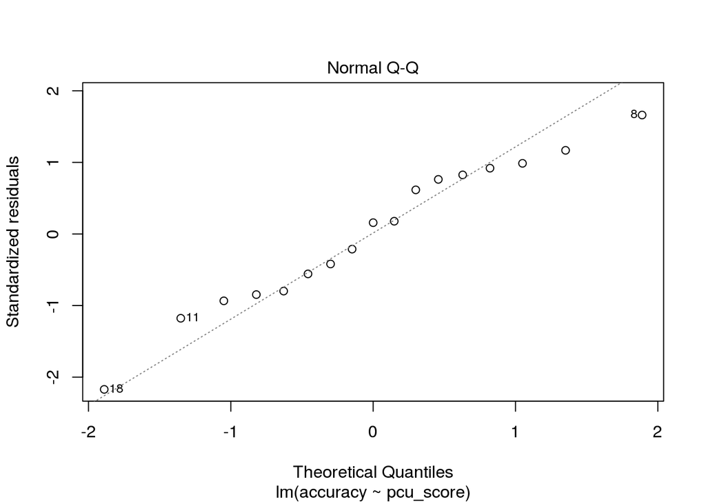

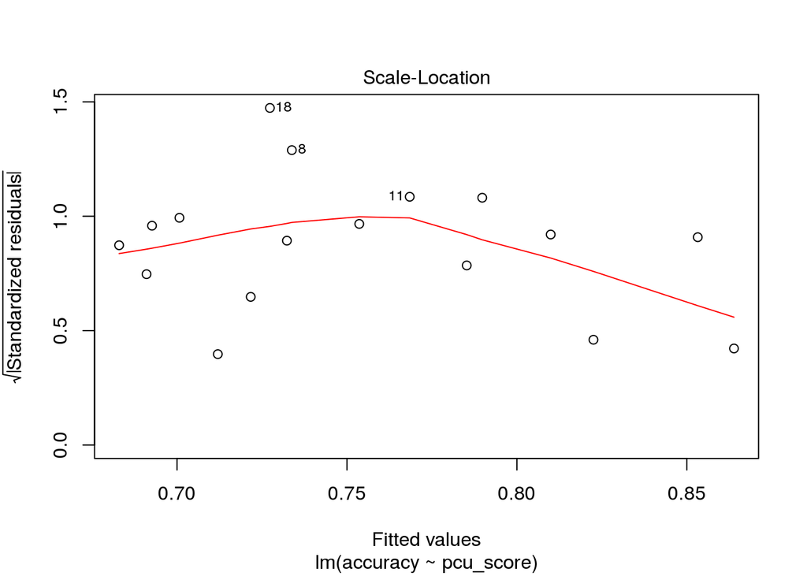

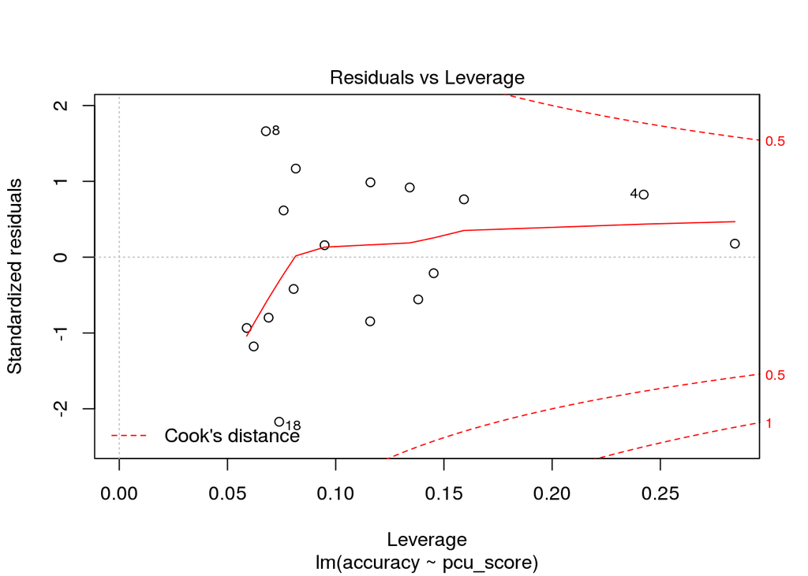

```r
plot(fm)
```

Remember that you can also access the information presented in summary and plot functions programmatically. See the documentation of lm for details.

```r
resid(fm) # residuals using a function resid
```

```
##            1            2            3            4            5
##  0.009544158  0.070953697 -0.012403617  0.045519090 -0.050453765
##            6            7            8            9           10
##  0.009514304 -0.057422061  0.101660495  0.058781210  0.037541993
##           11           12           14           15           16
## -0.072263268 -0.032805564  0.044305189 -0.025481201  0.054188856
##           17           18
## -0.048786382 -0.132393135
```

```r
fm$resid # residuals using $-notation
```

```
##            1            2            3            4            5
##  0.009544158  0.070953697 -0.012403617  0.045519090 -0.050453765
##            6            7            8            9           10
##  0.009514304 -0.057422061  0.101660495  0.058781210  0.037541993
##           11           12           14           15           16
## -0.072263268 -0.032805564  0.044305189 -0.025481201  0.054188856
##           17           18
## -0.048786382 -0.132393135
```

Finally, we could calculate the F-statistics for all the terms using the *anova* function. In this case, the relevant F statistic was already available in the summary because the model had only a single predictor.

```r
anova(fm)
```

```
## Analysis of Variance Table
##
## Response: accuracy
##           Df   Sum Sq  Mean Sq F value   Pr(>F)
## pcu_score  1 0.052190 0.052190  12.996 0.002599 **
## Residuals 15 0.060239 0.004016
## ---
## Signif. codes:  0 '***' 0.001 '**' 0.01 '*' 0.05 '.' 0.1 ' ' 1
```

## Association of pcu_score after control for gender

We could add categorical variables to the model, also.

```r
fm1 <- lm(accuracy ~ pcu_score, game.wmc)
summary(fm1)
```

```
##
## Call:
## lm(formula = accuracy ~ pcu_score, data = game.wmc)
##
## Residuals:
##       Min        1Q    Median        3Q       Max
## -0.132393 -0.048786  0.009514  0.045519  0.101660
##
## Coefficients:
##             Estimate Std. Error t value Pr(>|t|)
## (Intercept)  0.66200    0.03012  21.981    8e-13 ***
## pcu_score    0.17422    0.04833   3.605   0.0026 **
## ---
## Signif. codes:  0 '***' 0.001 '**' 0.01 '*' 0.05 '.' 0.1 ' ' 1
##
## Residual standard error: 0.06337 on 15 degrees of freedom
##   (1 observation deleted due to missingness)
## Multiple R-squared:  0.4642, Adjusted R-squared:  0.4285
## F-statistic:    13 on 1 and 15 DF,  p-value: 0.002599
```

```r
fm2 <- lm(accuracy ~ pcu_score + gender, game.wmc)
summary(fm2)
```

```
##
## Call:
## lm(formula = accuracy ~ pcu_score + gender, data = game.wmc)
##
## Residuals:
##      Min       1Q   Median       3Q      Max
## -0.13125 -0.04949  0.00855  0.04639  0.10095
##
## Coefficients:
##               Estimate Std. Error t value Pr(>|t|)
## (Intercept)   0.662551   0.032684  20.271 8.96e-12 ***
## pcu_score     0.174602   0.050468   3.460  0.00383 **
## genderNainen -0.001842   0.032612  -0.056  0.95577
## ---
## Signif. codes:  0 '***' 0.001 '**' 0.01 '*' 0.05 '.' 0.1 ' ' 1
##
## Residual standard error: 0.06559 on 14 degrees of freedom
##   (1 observation deleted due to missingness)
## Multiple R-squared:  0.4643, Adjusted R-squared:  0.3878
## F-statistic: 6.068 on 2 and 14 DF,  p-value: 0.01266
```

From the output, we can see that including the main effect of gender does not make the model better. We can test this explicitly.

```r
anova(fm1, fm2) # by default F-test
```

```
## Analysis of Variance Table
##
## Model 1: accuracy ~ pcu_score
## Model 2: accuracy ~ pcu_score + gender
##   Res.Df      RSS Df  Sum of Sq      F Pr(>F)
## 1     15 0.060239
## 2     14 0.060225  1 1.3718e-05 0.0032 0.9558
```

```r
anova(fm1, fm2, test="Chisq")
```

```
## Analysis of Variance Table
##
## Model 1: accuracy ~ pcu_score
## Model 2: accuracy ~ pcu_score + gender
##   Res.Df      RSS Df  Sum of Sq Pr(>Chi)
## 1     15 0.060239
## 2     14 0.060225  1 1.3718e-05    0.955
```